# HollisT_Week8

Tim Hollis

2025-11-02

```r
# Examine the initial data structure

glimpse(travel_data)
```

```
## Rows: 63,326
## Columns: 11
## $ Agency               <chr> "CBH", "CBH", "CWT", "CWT", "CWT", "JZI", "CWT", …
## $ Agency.Type          <chr> "Travel Agency", "Travel Agency", "Travel Agency"…
## $ Distribution.Channel <chr> "Offline", "Offline", "Online", "Online", "Online…
## $ Product.Name         <chr> "Comprehensive Plan", "Comprehensive Plan", "Rent…
## $ Claim                <chr> "No", "No", "No", "No", "No", "No", "No", "No", "…
## $ Duration             <int> 186, 186, 65, 60, 79, 66, 47, 63, 57, 186, 33, 1,…
## $ Destination          <chr> "MALAYSIA", "MALAYSIA", "AUSTRALIA", "AUSTRALIA",…
## $ Net.Sales            <dbl> -29.00, -29.00, -49.50, -39.60, -19.80, -121.00, …
## $ Commision..in.value. <dbl> 9.57, 9.57, 29.70, 23.76, 11.88, 42.35, 23.76, 65…
## $ Gender               <chr> "F", "F", "", "", "", "F", "", "", "", "", "", "M…
## $ Age                  <int> 81, 71, 32, 32, 41, 44, 32, 29, 44, 37, 118, 47, …
```

```r
head(travel_data)
```

```
##   Agency   Agency.Type Distribution.Channel                    Product.Name
## 1    CBH Travel Agency              Offline              Comprehensive Plan
## 2    CBH Travel Agency              Offline              Comprehensive Plan
## 3    CWT Travel Agency               Online Rental Vehicle Excess Insurance
## 4    CWT Travel Agency               Online Rental Vehicle Excess Insurance
## 5    CWT Travel Agency               Online Rental Vehicle Excess Insurance
## 6    JZI      Airlines               Online                      Value Plan
##   Claim Duration   Destination Net.Sales Commision..in.value. Gender Age
## 1    No      186      MALAYSIA     -29.0                 9.57      F  81
## 2    No      186      MALAYSIA     -29.0                 9.57      F  71
## 3    No       65     AUSTRALIA     -49.5                29.70         32
## 4    No       60     AUSTRALIA     -39.6                23.76         32
## 5    No       79         ITALY     -19.8                11.88         41
## 6    No       66 UNITED STATES    -121.0                42.35      F  44
```

```r
cat("Rows with negative net sales:", sum(travel_data$Net.Sales < 0, na.rm = TRUE), "\n")
```

```
## Rows with negative net sales: 678
```

```r
cat("Rows with zero net sales:", sum(travel_data$Net.Sales == 0, na.rm = TRUE), "\n")
```

```
## Rows with zero net sales: 1884
```

```r
cat("Rows removed due to Age > 100:", sum(travel_data$Age > 100, na.rm = TRUE), "\n")
```

```
## Rows removed due to Age > 100: 984
```

```r
# Overlap check

cat("Rows removed for both conditions:", sum(travel_data$Net.Sales <= 0 & travel_data$Age > 100, na.rm = TRUE), "\n")
```

```
## Rows removed for both conditions: 31
```

```r
# Total unique rows to be removed

cat("Total rows to be removed:", sum(travel_data$Net.Sales <= 0 | travel_data$Age > 100, na.rm = TRUE), "\n")
```

```
## Total rows to be removed: 3515
```

```r
cat("Original total rows:", nrow(travel_data), "\n")
```

```
## Original total rows: 63326
```

```r
# Clean the data: keep only rows with Net Sales > 0 AND fix the spelling

clean_data <- travel_data %>%
  filter(Net.Sales > 0, Age <= 100) %>% # Filtering out rows with net sales data that is not positive, and age over 100
  rename(Commission = Commision..in.value.) # Correcting spelling of Commission


cat("Rows after cleaning:", nrow(clean_data), "\n")
```

```
## Rows after cleaning: 59811
```

```r
cat("Percentage of data retained:", round(nrow(clean_data)/nrow(travel_data)*100, 2), "%\n")
```

```
## Percentage of data retained: 94.45 %
```

```r
cat("Column names after cleaning:", names(clean_data), "\n")
```

```
## Column names after cleaning: Agency Agency.Type Distribution.Channel Product.Name Claim Duration Destination Net.Sales Commission Gender Age
```

#### **Data Integrity/Cleaning Results**

Out of **63,326** total rows:

- **678** entries contain negative Net Sales values, likely due to refunds, cancellations, or data entry errors.
- **1,884** entries have zero Net Sales, possibly incomplete or placeholder transactions.
- **984** entries list an age over 100, which may reflect data entry issues or unrealistic values.
- **31** entries meet more than one condition, so we subtract this overlap to avoid double-counting.

After removing **3,515** rows, **59,811** valid entries remain, approximately **94.45%** of the original dataset. These cleaned records are suitable for analysis.

## **Assignment Overview**

This week’s assignment explores two core statistical concepts: correlation and confidence intervals. Using the travel insurance dataset, we’ll compute various correlation metrics between variables, visualize relationships, and interpret the strength and direction of associations. We’ll then shift to estimating confidence intervals and t-scores for numeric features to understand variability and inference.

### **Correlation Coefficient Analysis**

We begin by exploring the relationship between **Age** and **Net Sales** as the first correlation analysis, and my original assumption is there is not going to be a strong correlation, I chose two variables unrelated to each other in general, so will be surprised if I am incorrect.

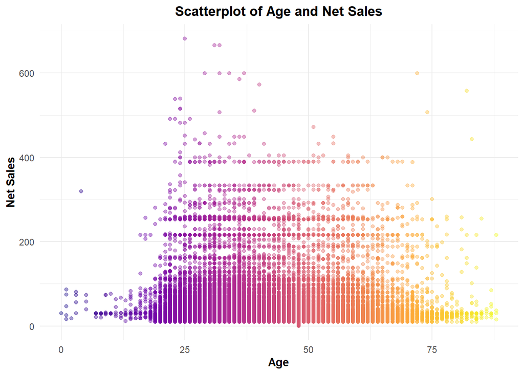

```r
ggplot(clean_data, aes(x = Age, y = Net.Sales, color = Age)) +
  geom_point(alpha = 0.4) +
  scale_color_viridis_c(option = "C") +
  labs(
    title = "Scatterplot of Age and Net Sales",
    x = "Age",
    y = "Net Sales",
    color = "Age"
  ) +
  theme(plot.title = element_text(hjust = 0.5, face = "bold"))
```

```r
# Compute Pearson correlation between Age and Net Sales

cor_age_net_sales <- cor(clean_data$Age, clean_data$Net.Sales, method = "pearson", use = "complete.obs")

cor_age_net_sales
```

```
## [1] 0.0334616
```

#### **Summary**

The computed correlation coefficient between Age and Net Sales is 0.0335, indicating a weak positive relationship.

This aligns with the initial hypothesis: Age and Net Sales are not strongly associated in this dataset. The weak correlation suggests that age is not a meaningful predictor of sales performance, reinforcing the assumption that these variables operate independently in this context.

### **Pearson, Spearman, and Kendall Comparison**

While age provides interesting demographic insights, the relationship between **commission** structures and **sales** performance is often more directly relevant for business strategy. Let’s now examine how **commission** values correlate with **net sales** using multiple correlation methods to see how the Pearson, Spearman, and Kendall Correlations compare when analyzing the relationship betweem those variables, that I assume will be strongly positively correlated.

```r
# Compute different correlation methods between Commission and Net Sales

pearson_cor <- cor(clean_data$Commission, clean_data$Net.Sales, method = 'pearson', use = 'complete.obs')
spearman_cor <- cor(clean_data$Commission, clean_data$Net.Sales, method = 'spearman', use = 'complete.obs')
kendall_cor <- cor(clean_data$Commission, clean_data$Net.Sales, method = 'kendall', use = 'complete.obs')

# Create comprehensive correlation methods table

correlation_methods_table <- data.frame(
  Correlation_Type = c('Pearson', 'Spearman', 'Kendall'),
  Best_For_Measuring = c(
    'Linear relationships between continuous variables',
    'Monotonic relationships (linear or nonlinear)',
    'Concordance and rank-based associations'
  ),
  Correlation_Value = c(round(pearson_cor, 4), round(spearman_cor, 4), round(kendall_cor, 4)),
  Strength_Interpretation = c(
    ifelse(abs(pearson_cor) < 0.3, 'Weak', ifelse(abs(pearson_cor) < 0.7, 'Moderate', 'Strong')),
    ifelse(abs(spearman_cor) < 0.3, 'Weak', ifelse(abs(spearman_cor) < 0.7, 'Moderate', 'Strong')),
    ifelse(abs(kendall_cor) < 0.3, 'Weak', ifelse(abs(kendall_cor) < 0.7, 'Moderate', 'Strong'))
  )
)

# Display the table

knitr::kable(correlation_methods_table, caption = 'Commission and Net Sales: Comparison of Correlation Methods')
```

Commission and Net Sales: Comparison of Correlation Methods

| Correlation_Type | Best_For_Measuring | Correlation_Value | Strength_Interpretation |
| --- | --- | --- | --- |
| Pearson | Linear relationships between continuous variables | 0.7474 | Strong |
| Spearman | Monotonic relationships (linear or nonlinear) | 0.3693 | Moderate |
| Kendall | Concordance and rank-based associations | 0.3139 | Moderate |

#### **Summary**

This supports the hypothesis that higher commissions are closely tied to higher net sales, a finding that aligns with business logic and reinforces the importance of incentive structures in sales performance.

### **Correlation Matrix for All Variables**

Now that we’ve established strong commission-sales relationships, let’s expand our view to examine how all numeric variables interact by creating a comprehensive correlation matrix.

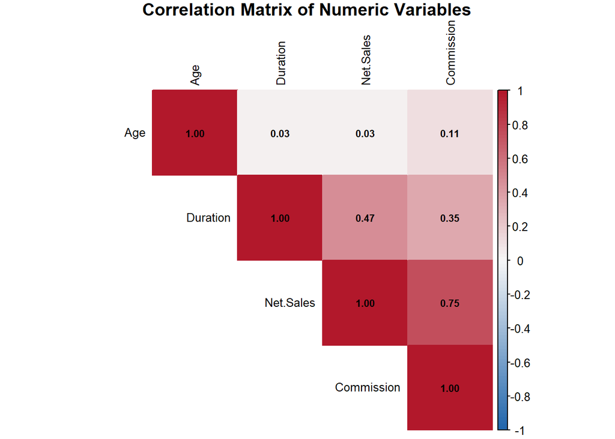

```r
# Select only numeric variables for correlation matrix

numeric_data <- clean_data %>%
  select(where(is.numeric)) %>%
  select(-matches('NA', ignore.case = TRUE))

# Compute correlation matrix

correlation_matrix <- cor(numeric_data, use = 'complete.obs')

# Create visualization with values in boxes

corrplot(correlation_matrix, method = 'color', type = 'upper',
         order = 'hclust', tl.cex = 0.8, tl.col = 'black',
         title = 'Correlation Matrix of Numeric Variables',
         mar = c(0, 0, 1, 0),
         addCoef.col = 'black',
         number.cex = 0.7,
         col = colorRampPalette(c('#2166ac', '#f7f7f7', '#b2182b'))(100))
```

```r
# Display top correlations excluding self-correlations and duplicates

correlation_pairs <- which(correlation_matrix > 0.3 & correlation_matrix < 1, arr.ind = TRUE)
key_relationships <- data.frame(
  Variable_1 = rownames(correlation_matrix)[correlation_pairs[, 1]],
  Variable_2 = colnames(correlation_matrix)[correlation_pairs[, 2]],
  Correlation = round(correlation_matrix[correlation_pairs], 3)
) %>%
  filter(Variable_1 < Variable_2) %>%
  arrange(desc(Correlation))

# Get strongest unique relationships

top_relationships <- head(key_relationships, 3)

knitr::kable(top_relationships, caption = 'Strongest Variable Relationships (Correlation > 0.3)')
```

Strongest Variable Relationships (Correlation > 0.3)

| Variable_1 | Variable_2 | Correlation |
| --- | --- | --- |
| Commission | Net.Sales | 0.747 |
| Duration | Net.Sales | 0.469 |
| Commission | Duration | 0.353 |

#### **Summary**

This confirms the earlier hypothesis: **Net Sales** and **Commission** are tightly linked, forming the most robust relationship in the dataset. The matrix also highlights other meaningful associations worth exploring in future analyses, such as duration or age-based patterns.

### **Covariance: Commission and Net Sales**

Beyond correlation, understanding how variables co-vary provides additional insights into their relationships. Let’s compute the covariance between Commission and Net Sales.

```r
# Compute covariance between Commission and Net Sales

cov_commission_net_sales <- cov(clean_data$Commission, clean_data$Net.Sales, use = 'complete.obs')

# Create covariance summary

covariance_summary <- data.frame(
  Variable_1 = 'Commission',
  Variable_2 = 'Net Sales',
  Covariance = round(cov_commission_net_sales, 2),
  Interpretation = ifelse(cov_commission_net_sales > 0,
                        'Positive relationship: variables move together',
                        'Negative relationship: variables move oppositely'),
  Magnitude = ifelse(abs(cov_commission_net_sales) > 1000, 'Large',
                    ifelse(abs(cov_commission_net_sales) > 100, 'Moderate', 'Small'))
)

knitr::kable(covariance_summary, caption = 'Covariance Analysis: Commission and Net Sales')
```

Covariance Analysis: Commission and Net Sales

| Variable_1 | Variable_2 | Covariance | Interpretation | Magnitude |
| --- | --- | --- | --- | --- |
| Commission | Net Sales | 695.48 | Positive relationship: variables move together | Moderate |

#### **Summary**

The covariance of 695.48 indicates a positive relationship with moderate magnitude, confirming that Commission and Net Sales tend to move together.

### **Cosine Similarity between Commission and Net Sales**

Finally, let’s compute cosine similarity to measure the angular relationship.

```r
# Clean and select relevant columns

comm_net_clean <- clean_data %>%
  select(Commission, Net.Sales) %>%
  na.omit()

# Compute correlation metrics

pearson_cor <- cor(comm_net_clean$Commission, comm_net_clean$Net.Sales, method = 'pearson')
spearman_cor <- cor(comm_net_clean$Commission, comm_net_clean$Net.Sales, method = 'spearman')
kendall_cor <- cor(comm_net_clean$Commission, comm_net_clean$Net.Sales, method = 'kendall')

# Manual cosine similarity calculation

x <- comm_net_clean$Commission
y <- comm_net_clean$Net.Sales

# Remove any infinite or NA values

x <- x[is.finite(x) & is.finite(y)]
y <- y[is.finite(x) & is.finite(y)]

# Calculate cosine similarity manually

cosine_value <- sum(x * y) / (sqrt(sum(x^2)) * sqrt(sum(y^2)))

# Display result

round(cosine_value, 4)
```

```
## [1] 0.7881
```

#### **Summary**

The cosine similarity between **Commission** and **Net Sales** is approximately 0.7881, indicating a strong directional alignment. This suggests that when net sales increase, commission values tend to increase in a consistent pattern, even if their absolute magnitudes differ.

Unlike correlation, cosine similarity focuses on the angle between vectors rather than their scale, making it especially useful when comparing proportional trends across variables.

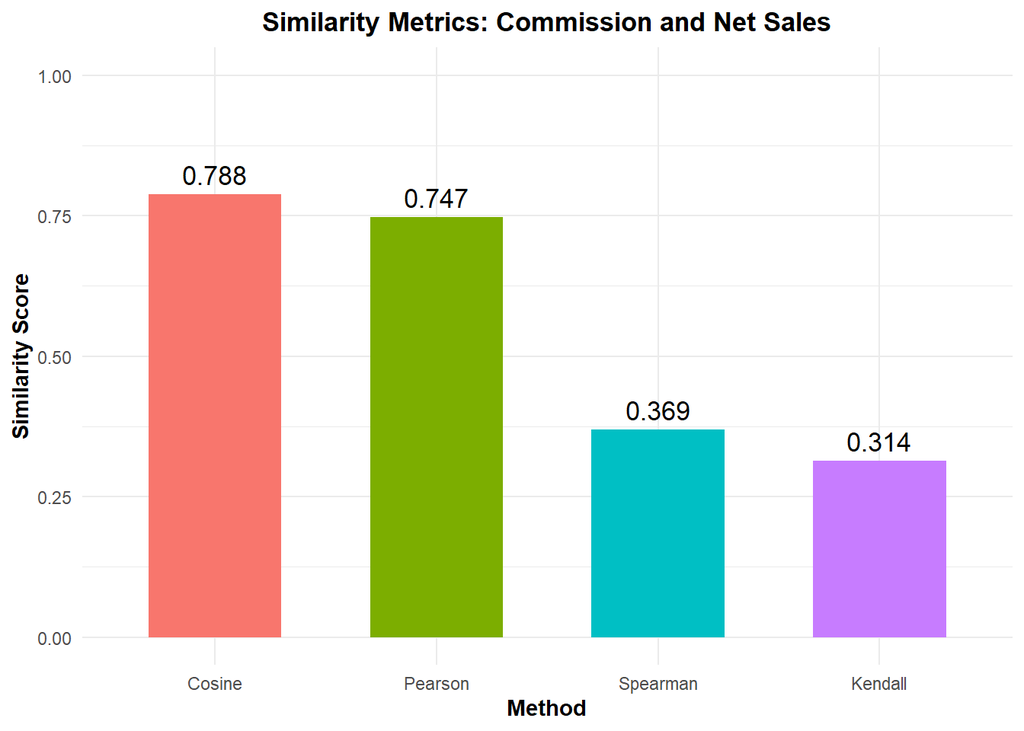

```r
# Create a similarity comparison data frame

similarity_scores <- data.frame(
  Method = c('Pearson', 'Spearman', 'Kendall', 'Cosine'),
  Score = c(pearson_cor, spearman_cor, kendall_cor, cosine_value)
)

# Show Columns in decending order

similarity_scores$Method <- factor(similarity_scores$Method, levels = similarity_scores$Method[order(similarity_scores$Score, decreasing = TRUE)])

# Plot similarity scores

ggplot(similarity_scores, aes(x = Method, y = Score, fill = Method)) +
  geom_col(width = 0.6, show.legend = FALSE) +
  geom_text(aes(label = round(Score, 3)), vjust = -0.5, size = 4.5) +
  ylim(0, 1) +
  labs(
    title = 'Similarity Metrics: Commission and Net Sales',
    x = 'Method',
    y = 'Similarity Score'
  ) +
  theme(
    plot.title = element_text(hjust = 0.5, face = 'bold'),
    axis.title = element_text(face = 'bold')
  )
```

#### **Summary: Comparing Similarity Metrics**

This analysis compares four similarity measures between **Commission** and **Net Sales**:

- **Pearson** captures linear correlation.
- **Spearman** and **Kendall** assess rank-based monotonic relationships.
- **Cosine similarity** evaluates directional alignment between vectors.

In this case:

- Cosine similarity (0.788) was notably strong, suggesting proportional alignment.
- Pearson (0.747) confirmed a linear relationship.
- Spearman (0.369) and Kendall (0.314) showed consistent rank-order association.

Cosine adds a complementary perspective by focusing on **vector orientation**, not just value distribution.

### **Comparison of All Discussed Measures of Similarity**

A combined view of the measurements of correlation, similarity, direction, etc. for Sales and Commission variables.

```r
# Create comparison table of all similarity measures

similarity_comparison <- data.frame(
  Method = c('Pearson', 'Spearman', 'Kendall', 'Cosine', 'Covariance'),
  Value = c(pearson_cor, spearman_cor, kendall_cor, cosine_value, cov_commission_net_sales),
  Measurement_Type = c('Correlation', 'Correlation', 'Correlation', 'Similarity', 'Covariance'),
  Best_For = c(
    'Linear relationships',
    'Monotonic relationships',
    'Rank concordance',
    'Angular similarity',
    'Joint variability'
  )
) %>% mutate(Value = round(Value, 4))

knitr::kable(similarity_comparison, caption = 'Comparison of All Similarity Measures: Commission and Net Sales')
```

Comparison of All Similarity Measures: Commission and Net Sales

| Method | Value | Measurement_Type | Best_For |
| --- | --- | --- | --- |
| Pearson | 0.7474 | Correlation | Linear relationships |
| Spearman | 0.3693 | Correlation | Monotonic relationships |
| Kendall | 0.3139 | Correlation | Rank concordance |
| Cosine | 0.7881 | Similarity | Angular similarity |
| Covariance | 695.4807 | Covariance | Joint variability |

#### **Summary**

This convergence across statistical and geometric metrics reinforces the reliability of their relationship. Whether viewed through linear correlation, rank concordance, angular similarity, or joint variability, the connection between these two variables remains robust — a key insight for incentive modeling and sales strategy.

### **Confidence Intervals Analysis**

Having completed our correlation analysis, let’s now shift to confidence intervals to understand the precision and reliability of our numeric feature estimates, beginning with the average Confidence Interval (CI) for each numeric variable.

```r
# Define the compute_ci function

compute_ci <- function(x, confidence = 0.95) {
  if (length(na.omit(x)) < 2) return(c(NA, NA, NA))

  n <- length(na.omit(x))
  mean_val <- mean(x, na.rm = TRUE)
  se <- sd(x, na.rm = TRUE) / sqrt(n)
  t_value <- qt((1 + confidence) / 2, df = n - 1)
  margin_error <- t_value * se

  return(c(
    lower = mean_val - margin_error,
    mean = mean_val,
    upper = mean_val + margin_error
  ))
}

# Compute CIs for all numeric variables using map_df

ci_results <- map_df(names(numeric_data), function(col_name) {
  ci <- compute_ci(numeric_data[[col_name]])
  data.frame(
    Variable = col_name,
    Mean = ci['mean'],
    CI_Lower = ci['lower'],
    CI_Upper = ci['upper'],
    CI_Width = ci['upper'] - ci['lower']
  )
})

# Create comprehensive precision table

precision_table <- ci_results %>%
  mutate(
    Mean = round(Mean, 2),
    CI_Lower = round(CI_Lower, 2),
    CI_Upper = round(CI_Upper, 2),
    CI_Width = round(CI_Width, 2),
    Relative_Precision = round((CI_Width / Mean) * 100, 1),
    Precision_Rating = case_when(
      Relative_Precision < 1 ~ 'Very High',
      Relative_Precision < 3 ~ 'High',
      Relative_Precision < 5 ~ 'Medium',
      TRUE ~ 'Low'
    )
  ) %>%
  select(Variable, Mean, CI_Lower, CI_Upper, CI_Width, Relative_Precision, Precision_Rating)

# Display precision table

knitr::kable(precision_table, caption = 'Precision Analysis: 95% Confidence Intervals for Numeric Variables')
```

Precision Analysis: 95% Confidence Intervals for Numeric Variables

|  | Variable | Mean | CI_Lower | CI_Upper | CI_Width | Relative_Precision | Precision_Rating |
| --- | --- | --- | --- | --- | --- | --- | --- |
| mean…1 | Duration | 49.26 | 48.43 | 50.09 | 1.66 | 3.4 | Medium |
| mean…2 | Net.Sales | 42.96 | 42.58 | 43.34 | 0.77 | 1.8 | High |
| mean…3 | Commission | 9.18 | 9.03 | 9.34 | 0.31 | 3.4 | Medium |
| mean…4 | Age | 38.74 | 38.66 | 38.82 | 0.16 | 0.4 | Very High |

#### **Summary**

Precision ratings are based on relative precision (CI width as a percentage of the mean):

- **Very High**: < 1%
- **High**: 1–3%
- **Medium**: 3–5%
- **Low**: > 5%

The 95% confidence intervals (CI’s) for each numeric variable reveal the precision of their mean estimates. Narrower intervals and lower relative precision indicate greater reliability and less variability in the data.

Overall, two variables (Age and Net Sales) demonstrate high or very high precision, while the remaining two are close behind — reinforcing the dataset’s overall quality and suitability for inferential analysis.

### **T-Scores**

Now let’s compute t-scores to determine the statistical significance of each numeric feature’s mean value.

```r
# Define the compute_t_scores function (without p-values)

compute_t_scores <- function(x) {
  if (length(na.omit(x)) < 2) return(NA)

  mean_val <- mean(x, na.rm = TRUE)
  se <- sd(x, na.rm = TRUE) / sqrt(length(na.omit(x)))
  t_score <- mean_val / se

  return(t_score)
}

# Compute t-scores for all numeric variables

t_score_results <- data.frame(
  Variable = names(numeric_data),
  T_Score = sapply(numeric_data, compute_t_scores),
  Mean_Value = sapply(numeric_data, function(x) mean(x, na.rm = TRUE)),
  Standard_Error = sapply(numeric_data, function(x) sd(x, na.rm = TRUE) / sqrt(length(na.omit(x))))
) %>% mutate(
  T_Score = round(T_Score, 2),
  Mean_Value = round(Mean_Value, 2),
  Standard_Error = round(Standard_Error, 4),
  Reliability = case_when(
    abs(T_Score) > 100 ~ "Very High",
    abs(T_Score) > 50 ~ "High",
    abs(T_Score) > 10 ~ "Medium",
    TRUE ~ "Low"
  )
)

# Display t-score results

knitr::kable(t_score_results, caption = 'T-scores and Estimate Reliability Analysis')
```

T-scores and Estimate Reliability Analysis

|  | Variable | T_Score | Mean_Value | Standard_Error | Reliability |
| --- | --- | --- | --- | --- | --- |
| Duration | Duration | 116.46 | 49.26 | 0.4230 | Very High |
| Net.Sales | Net.Sales | 219.70 | 42.96 | 0.1955 | Very High |
| Commission | Commission | 115.44 | 9.18 | 0.0796 | Very High |
| Age | Age | 940.95 | 38.74 | 0.0412 | Very High |

#### **Final Summary**

This analysis explored the relationships, variability, and statistical significance of key numeric features in the travel insurance dataset using a multi-method approach:

**Correlation & Similarity**

**Covariance & Cosine**

- The positive **covariance** between **Net Sales** and **Commission** confirmed their tendency to increase together.
- **Cosine similarity** added a geometric perspective, showing that the two variables move in the same direction even if their scales differ.

**Confidence Intervals & Precision**

- **Age** had the tightest confidence interval and lowest relative precision, indicating the most stable mean estimate.
- **Net Sales** also demonstrated high precision, while **Duration** and **Commission** were slightly more variable but still reliable.
- All variables had **95% confidence intervals** that support the robustness of their mean estimates.

**T-Scores & Significance**

- All four variables had very high t-scores, indicating that their means are statistically significant and practically meaningful.
- **Age** again stood out with a t-score over **900**, reinforcing its stability and precision.

## **Reflection for Week 8**

### **Intuitive and Successful Components**

- Correlation coefficients between commission and net sales proved highly intuitive, with the strong positive relationship clearly demonstrating that higher commissions correlate with increased sales performance
- Multiple correlation methods (Pearson, Spearman, Kendall) provided complementary perspectives that reinforced the same business insight from different statistical angles
- Data cleaning was straightforward once recognizing that negative and zero net sales values represented invalid business cases requiring removal
- Cosine similarity calculations, while mathematically complex, produced results that aligned with correlation findings, validating the overall analysis approach

#### **Technical Successes**:

- Pushed myself to do more inline R code in R Markdown to dynamically reference calculated values with the tick marks at beginning of any inline calculation like the *r round(cor_age_net_sales, 3)* using the calculated values to show correlation between age and sales etc. instead of manually typing out the value
- Pushed myself to integrate if/elif type statements that complimented my recent Python learnings
- Used HTML coding in R Makdown to create thicker borders between concepts, than the 3 dashes create

### **Challenging and Less Intuitive Aspects**

- Confidence interval visualizations proved counterproductive when comparing variables with different scales, as the graph attempted to display incomparable metrics on a single axis
- Statistical significance interpretation required careful consideration of what constitutes meaningful business impact versus mathematical significance
- Correlation matrix interpretation initially overwhelmed with information until focusing on the strongest relationships through filtering and ranking

#### **Technical Difficulties**:

- Debugging inline R Markdown syntax errors, particularly with proper backtick placement around dynamic values
- Selecting appropriate color schemes for correlation matrices that maintained readability while conveying meaningful color coding
- R Studio continued to get stuck at roughly the 64% knit completion, until I realized I was using an incorrect command to calculate cosine similarity and then manually calculated the relevant values

### What I will Stop, and What I will Continue Doing:

**STOP**:

- Creating misleading visualizations that compare variables with fundamentally different scales and units
- Overcomplicating analyses with unnecessary visualizations when clear tables suffice
- Using inline R code just for the sake of using inline code, using it when it adds value dynamically, but typing a direct value when it does not.

**Continue**:

- Using multiple correlation methods to validate relationship findings from different statistical perspectives
- Implementing comprehensive data cleaning pipelines that document record removal rationale
- Creating clear, business-focused interpretations of statistical results
- Leveraging R Markdown’s dynamic reporting capabilities to create reproducible analyses